# Untitled

hyo

2020 3 13

## 1. R 시작

```r
setwd("C:/Users/haley/Desktop/haley/task/Rbasic/statistic_lecture/basic123")
getwd()
```

```
## [1] "C:/Users/haley/Desktop/haley/task/Rbasic/statistic_lecture/basic123"
```

- working directory를 설정 후 작업을 하는것이 좋음

[figure not shown]

- 위의 하이라이트 된부분을 복사하여 역슬래쉬 \ 를 슬래쉬 /로 바꾸어 working directory를 설정한다

### 1.1 R기초 문법

#### 1.1.1 Vector

##### Variables

- type을 알아야하는 이유? - 내가 분석하고자하는것이 숫자인데
- 문자처리가 되어있다면 우린 전처리를 “1” -> 1로 바꿔줘야함
- double은 실수를 의미하며, L로 integer(정수값)을 표현 할 수 있음

```r
x1 = 3.5 #double
typeof(x1)
```

```
## [1] "double"
```

```r
x2 = 3
typeof(x2)
```

```
## [1] "double"
```

```r
x3 = 3L #3 integer
typeof(x3)
```

```
## [1] "integer"
```

##### Variables

- ""을 사용하여 문자를 표현
- 숫자에 “숫자”를 코딩하면 문자화됨
- as.numeric을 활용하여 문자화된 숫자를 숫자로 표현 가능

```r
x4 = "a"
typeof(x4)
```

```
## [1] "character"
```

```r
x5 = TRUE
typeof(x5)
```

```
## [1] "logical"
```

```r
q = "33"
typeof(q)
```

```
## [1] "character"
```

```r
q1 = as.numeric(q)
typeof(q1)
```

```
## [1] "double"
```

##### Variables

- integer와 double을 더하면 double이됨

```r
x6 = x1 + x3 #double로 바뀜
typeof(x6)
```

```
## [1] "double"
```

```r
x6
```

```
## [1] 6.5
```

##### Creating vector

- c()를 사용하여 벡터들을 묶어 x변수에 넣을 수 있음
- 이때의 값이 하나라도 문자라면 모두 문자화 됨(character)

```r
x = c(3)
print(x)
```

```
## [1] 3
```

```r
typeof(x)
```

```
## [1] "double"
```

```r
x = c("a", 15, 12, 13)
x
```

```
## [1] "a"  "15" "12" "13"
```

```r
typeof(x)
```

```
## [1] "character"
```

##### Creating vector

- “:”을 사용하여 1씩 증가/감소하는 벡터를 만들 수 있음

```r
1:5
```

```
## [1] 1 2 3 4 5
```

```r
3:(-2)
```

```
## [1]  3  2  1  0 -1 -2
```

```r
(3.1):(5.5)
```

```
## [1] 3.1 4.1 5.1
```

```r
(5.5):(1.5)
```

```
## [1] 5.5 4.5 3.5 2.5 1.5
```

##### Creating vector

- c()를 통해 벡터를 결합할 수 있음

```r
x1 = 1:3
x2 = 10:5
x3 = c(x2,x1)
x3
```

```
## [1] 10  9  8  7  6  5  1  2  3
```

##### Useful functions to create vectors

- seq 함수를 활용하여 규칙이 있는 벡터를 만들 수 있다
  - 12 부터 30까지 by는 2단위로 증가하는 데이터
  - length는 사이의 4개 숫자 출력

```r
y = seq(from = 12, to = 30, by = 2)
y
```

```
##  [1] 12 14 16 18 20 22 24 26 28 30
```

```r
y = seq(12, 30, length = 4)
y
```

```
## [1] 12 18 24 30
```

##### Useful functions to create vectors

```r
x1 = rep(8, 4)
x2 = rep( c(5, 12, 13), 3)
x3 = rep( c(5, 12, 13), each = 3)
x1
```

```
## [1] 8 8 8 8
```

```r
x2
```

```
## [1]  5 12 13  5 12 13  5 12 13
```

```r
x3
```

```
## [1]  5  5  5 12 12 12 13 13 13
```

##### Slicing vector I

- 데이터이름 뒤에 대괄호 []를 사용하여 데이터 위치를 설정해주면 데이터를 선택할 수 있음
- 마이너스(-) 기호를 사용하면 해당 위치의 값이 사라진다

```r
x = 5:8
x
```

```
## [1] 5 6 7 8
```

```r
x1 = x[1:3]
x1
```

```
## [1] 5 6 7
```

```r
xnew = x[-2]
xnew
```

```
## [1] 5 7 8
```

```r
x2 = c(x1[1:3], 10, x[4])
x2
```

```
## [1]  5  6  7 10  8
```

##### Slicing vector II

```r
y = c(1.2, 3.9, 0.4, 0.12)
y[c(1, 3)]
```

```
## [1] 1.2 0.4
```

```r
y[2:3]
```

```
## [1] 3.9 0.4
```

```r
v = 3:4
y[v]
```

```
## [1] 0.40 0.12
```

```r
y[c(1, 1, 2)]
```

```
## [1] 1.2 1.2 3.9
```

##### Slicing vector III

- length()는 벡터의 갯수를 알려준다

```r
y[-c(1,2)]
```

```
## [1] 0.40 0.12
```

```r
y[-length(y)]
```

```
## [1] 1.2 3.9 0.4
```

##### Length of vector

```r
x = 3:6
length(x)
```

```
## [1] 4
```

```r
1:length(x)
```

```
## [1] 1 2 3 4
```

##### Operation on vector

- 벡터끼리의 사칙연산이 다음과 같이 가능
  - 각 위치별로 사칙연산이 수행되어짐을 아래의 예제를 통해 알 수 있다

```r
x1 = c(5,0, -4)
x2 = c(1, 2, 2)

x1+x2
```

```
## [1]  6  2 -2
```

```r
x1*x2
```

```
## [1]  5  0 -8
```

```r
x1/x2
```

```
## [1]  5  0 -2
```

##### Operation on vector

- 벡터의 갯수가 다르다면?
  - 적은 숫자의 벡터 값이 반복되어 계산되어진다

```r
x1 + 3
```

```
## [1]  8  3 -1
```

```r
x1*2
```

```
## [1] 10  0 -8
```

```r
x1 = c(5,0,-4,2)
x2 = c(2,1)
x1/x2
```

```
## [1]  2.5  0.0 -2.0  2.0
```

##### Order of operations

- 괄호를 사용하지 않은 것은 차이가 있으므로 주의 필요!
  - y1은 1부터 10까지의 벡터를 각각 1씩 감소해줌
  - y2는 1부터 (10-1)인 9의 값까지의 벡터를 뜻함

```r
y1 = 1:10-1
y1
```

```
##  [1] 0 1 2 3 4 5 6 7 8 9
```

```r
y2 = 1:(10-1)
y2
```

```
## [1] 1 2 3 4 5 6 7 8 9
```

##### useful operation

- 벡터 또는 어떠한 특정 값을 넣기 위해서 “=” 또는 “<-”기호가 사용되어진다
- 제곱, 몫, 나머지는 다음과 같은 함수로 연산되어진다

```r
x <- 11
x^2 #제곱
```

```
## [1] 121
```

```r
x%/%5 #몫
```

```
## [1] 2
```

```r
x%%5 #나머지
```

```
## [1] 1
```

##### Logical operation

- not을 표현하기 위해 “=”기호 앞에 “!” 사용

```r
6<7
```

```
## [1] TRUE
```

```r
6<=7
```

```
## [1] TRUE
```

```r
6==7 #같은지 여부
```

```
## [1] FALSE
```

```r
6!=7 #다른지 여부
```

```
## [1] TRUE
```

##### Logical operation

- indexing과 logical operation을 활용하여 원하는 데이터를 선택할 수 있음

```r
z = c(5, 2, -3, 8)
z^2
```

```
## [1] 25  4  9 64
```

```r
z[z^2 > 8]
```

```
## [1]  5 -3  8
```

```r
z[z%%2==1]
```

```
## [1]  5 -3
```

##### Slicing vector II (filtering)

```r
z[z>0]
```

```
## [1] 5 2 8
```

```r
z[z^2>8]
```

```
## [1]  5 -3  8
```

- z벡터에서 0보다 큰 값만을 추출
- z벡터에서 z의 제곱값이 8보다 큰 값만을 추출

##### Slicing vector II (filtering)

- which 함수는 logical operation이 true값인 위치를 알려줌
  - which(x>1)의 경우 x가 1보다 큰 3과 4의 위치인 1,3을 출력
  - which(x>1) 값이 1,3이므로 x[which(x>1)] = x[c(1,3)] => 3,4의 값이 출력됨

```r
x = c(3,1,4,1)
x[x>1]
```

```
## [1] 3 4
```

```r
which(x>1)
```

```
## [1] 1 3
```

```r
x[which(x>1)]
```

```
## [1] 3 4
```

##### `%in%` function

- 데이터 처리시 많이 사용되어짐
- 아래 예제 match 함수보다 함수 계산 속도가 %in%가 더 빠름

```r
1 %in% c(2,1,4)
```

```
## [1] TRUE
```

```r
c(1,5) %in% c(2,1,5)
```

```
## [1] TRUE TRUE
```

```r
c(1,5,3) %in% c(2,1,5)
```

```
## [1]  TRUE  TRUE FALSE
```

```r
x = c(3,1,4,1)
x%in% c(2,1,4)
```

```
## [1] FALSE  TRUE  TRUE  TRUE
```

```r
x = c("a","b","c")
"a" %in% x
```

```
## [1] TRUE
```

##### `match()` function

- 데이터 처리 인덱싱에 필요한 함수로써 특정 값을 찾을때 유용하게 쓰이는 함수

```r
match(1 ,c(2,1,4))
```

```
## [1] 2
```

```r
match(c(1,4),c(2,1,4))
```

```
## [1] 2 3
```

```r
x <- c(3,1,4,1)
match(x ,c(2,1,4))
```

```
## [1] NA  2  3  2
```

#### 1.1.2 Matrix

##### Create matrix

- nrow: 행의 수, ncol: 열의 수
- byrow=T: 행으로 나열

```r
y1 = matrix( c(1, 2, 3, 4), nrow = 2, ncol = 2)
y1
```

```
##      [,1] [,2]
## [1,]    1    3
## [2,]    2    4
```

```r
y2= matrix( c(1, 2, 3, 4), nrow = 2, ncol = 2, byrow = T)
y2
```

```
##      [,1] [,2]
## [1,]    1    2
## [2,]    3    4
```

##### Create matrix

- matrix(벡터,nrow,ncol) : nrow*ncol행렬
  - y[1,1]의 경우 1행,1열에 있는 값을 출력
  - y[,1]의 경우 모든행,1열에 있는 값을 벡터형태로 출력
  - 마이너스(-)의 경우 해당 행,열의 값들이 삭제되어짐

```r
y = matrix(c(1,3,4,5,1,3,4,1,5),3,3)
y
```

```
##      [,1] [,2] [,3]
## [1,]    1    5    4
## [2,]    3    1    1
## [3,]    4    3    5
```

```r
y[1, 1]
```

```
## [1] 1
```

```r
y[, 1] #벡터화됨
```

```
## [1] 1 3 4
```

```r
matrix(c(1,3,4),1,3)
```

```
##      [,1] [,2] [,3]
## [1,]    1    3    4
```

```r
y[-2,]
```

```
##      [,1] [,2] [,3]
## [1,]    1    5    4
## [2,]    4    3    5
```

```r
y[, -1]
```

```
##      [,1] [,2]
## [1,]    5    4
## [2,]    1    1
## [3,]    3    5
```

```r
y[-c(2,3),]
```

```
## [1] 1 5 4
```

##### Matrix function

- class() : 데이터의 형태를 알려줌
- dim() : 각 행,열의 정보를 알려줌
- ncol() : 열의 갯수
- nrow() : 행의 갯수

```r
class(y)
```

```
## [1] "matrix"
```

```r
dim(y)
```

```
## [1] 3 3
```

```r
ncol(y)
```

```
## [1] 3
```

```r
nrow(y)
```

```
## [1] 3
```

##### column bind and row bind

- 행렬을 결합하는 방법에는 행결합, 열결합이 있다

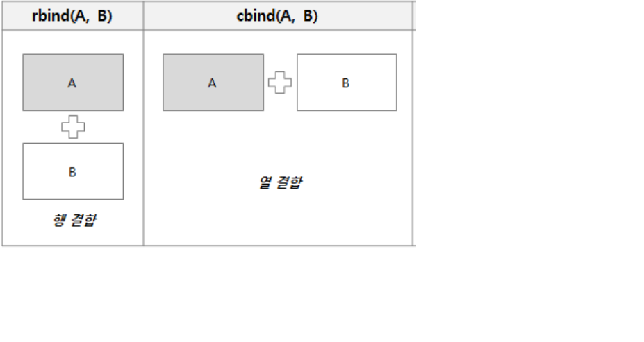

- rep(1,4)을 활용하여 1이 4번 반복된 데이터를 만든다
- z는 4*3행렬
- matrix z와 벡터형태의 one을 cbind(열 결합)를 하면 다음과 같다

```r
one = rep(1,4)
z = matrix( c(5:8, rep(-1,4), rep(0,4)), 4, 3)
z
```

```
##      [,1] [,2] [,3]
## [1,]    5   -1    0
## [2,]    6   -1    0
## [3,]    7   -1    0
## [4,]    8   -1    0
```

```r
one
```

```
## [1] 1 1 1 1
```

```r
cbind(z,one)
```

```
##             one
## [1,] 5 -1 0   1
## [2,] 6 -1 0   1
## [3,] 7 -1 0   1
## [4,] 8 -1 0   1
```

##### column bind and row bind

- rbind는 행결합으로 벡터 c(2,3,4)와 matrix z를 결합하게 되면 z1의 결과가 나온다

```r
z1 = rbind(c(2,3,4), z)
z1
```

```
##      [,1] [,2] [,3]
## [1,]    2    3    4
## [2,]    5   -1    0
## [3,]    6   -1    0
## [4,]    7   -1    0
## [5,]    8   -1    0
```

#### 1.1.3 Dataframe

- dataframe을 만드는 방법에는 여러가지다
- dataframe은 matrix의 일종

##### Create dataframe I

```r
x = 1:10
x
```

```
##  [1]  1  2  3  4  5  6  7  8  9 10
```

```r
x[1] = "a"
x
```

```
##  [1] "a"  "2"  "3"  "4"  "5"  "6"  "7"  "8"  "9"  "10"
```

```r
typeof(x[2])
```

```
## [1] "character"
```

```r
x
```

```
##  [1] "a"  "2"  "3"  "4"  "5"  "6"  "7"  "8"  "9"  "10"
```

```r
x = matrix(1:4,2,2)
x
```

```
##      [,1] [,2]
## [1,]    1    3
## [2,]    2    4
```

```r
x[2,2] = 8
x
```

```
##      [,1] [,2]
## [1,]    1    3
## [2,]    2    8
```

```r
typeof(x)
```

```
## [1] "double"
```

```r
x
```

```
##      [,1] [,2]
## [1,]    1    3
## [2,]    2    8
```

##### Create dataframe II

- kids와 ages라는 벡터형태의 변수를 만든다
- data.frame() 함수를 활용하여 2행2열 데이터 프레임을 만들 수 있다

```r
kids = c("Jack", "Jill")
ages = c(12, 10)
d = data.frame(kids, ages)
d
```

```
##   kids ages
## 1 Jack   12
## 2 Jill   10
```

##### Create dataframe III

- data.frame() 함수 안에 직접 변수명과 값을 입력하여 데이터프레임을 만들 수 있다

```r
v=data.frame(x1 = c(1,2),
             x2 = c("a","b"),
             x3 = factor(c("c","d"))
             )
v
```

```
##   x1 x2 x3
## 1  1  a  c
## 2  2  b  d
```

##### Selecting the elements

- 데이터 프레임의 변수를 선택하는 방법은 다음과 같다
- class는 factor값으로 알파벳 순으로 순서화되어진다
- 순서화는 stringsAsFactors = F 를 활용하여 제거 할 수 있다 (character로 바뀌게 됨)
- names()함수를 통해 데이터프레임의 변수 명들을 파악할 수 있다

```r
d$kids
```

```
## [1] Jack Jill
## Levels: Jack Jill
```

```r
class(d$kids) #class확인
```

```
## [1] "factor"
```

```r
d = data.frame(kids, ages,stringsAsFactors = F)
class(d$kids)
```

```
## [1] "character"
```

```r
names(d)
```

```
## [1] "kids" "ages"
```

##### Selecting the elements

- 데이터프레임안의 값을 선택해보자
- 데이터프레임의 인덱싱은 대괄호를 사용하며 첫번째 값은 행의자리, 두번째값은 열의 자리이다
  - d[1,] : 1행의 모든값
  - d[,1] : 1열의 모든값
  - d[1,1]: 1행 1열의 값

```r
d[1,]
```

```
##   kids ages
## 1 Jack   12
```

```r
d[,1]
```

```
## [1] "Jack" "Jill"
```

```r
d[1,1]
```

```
## [1] "Jack"
```

##### cbind/rbind

- 행,열 결합시 이름에 주의!
  - 행끼리의 결합인 rbind는 데이터변수 명이 같아야함
  - 열끼리의 결합인 cbind는 데이터변수명이 상관없지만 indexing을 위해서는 다른것이 좋음
  - 만약 열끼리의 결합 시 변수명이 동일하다면 names() = c() 함수를 사용하여 바꾸어주는 것이 좋다

```r
A = data.frame(x1 = rep(0,10), x2 = rep('b',10))
B = data.frame(x3 = rep(1,10), x4 = rep('d',10))
C = data.frame(x1 = rep(1,10), x2 = rep('d',10))
A
```

```
##    x1 x2
## 1   0  b
## 2   0  b
## 3   0  b
## 4   0  b
## 5   0  b
## 6   0  b
## 7   0  b
## 8   0  b
## 9   0  b
## 10  0  b
```

```r
B
```

```
##    x3 x4
## 1   1  d
## 2   1  d
## 3   1  d
## 4   1  d
## 5   1  d
## 6   1  d
## 7   1  d
## 8   1  d
## 9   1  d
## 10  1  d
```

```r
C
```

```
##    x1 x2
## 1   1  d
## 2   1  d
## 3   1  d
## 4   1  d
## 5   1  d
## 6   1  d
## 7   1  d
## 8   1  d
## 9   1  d
## 10  1  d
```

```r
cbindAB = cbind(A,B)
cbindAB
```

```
##    x1 x2 x3 x4
## 1   0  b  1  d
## 2   0  b  1  d
## 3   0  b  1  d
## 4   0  b  1  d
## 5   0  b  1  d
## 6   0  b  1  d
## 7   0  b  1  d
## 8   0  b  1  d
## 9   0  b  1  d
## 10  0  b  1  d
```

```r
cbindAC = cbind(A,C)
cbindAC
```

```
##    x1 x2 x1 x2
## 1   0  b  1  d
## 2   0  b  1  d
## 3   0  b  1  d
## 4   0  b  1  d
## 5   0  b  1  d
## 6   0  b  1  d
## 7   0  b  1  d
## 8   0  b  1  d
## 9   0  b  1  d
## 10  0  b  1  d
```

```r
rbindAC = rbind(A,C)
rbindAC
```

```
##    x1 x2
## 1   0  b
## 2   0  b
## 3   0  b
## 4   0  b
## 5   0  b
## 6   0  b
## 7   0  b
## 8   0  b
## 9   0  b
## 10  0  b
## 11  1  d
## 12  1  d
## 13  1  d
## 14  1  d
## 15  1  d
## 16  1  d
## 17  1  d
## 18  1  d
## 19  1  d
## 20  1  d
```

```r
names(cbindAC) = c("x1_A","x2_A","x1_B","x2_B")
cbindAC
```

```
##    x1_A x2_A x1_B x2_B
## 1     0    b    1    d
## 2     0    b    1    d
## 3     0    b    1    d
## 4     0    b    1    d
## 5     0    b    1    d
## 6     0    b    1    d
## 7     0    b    1    d
## 8     0    b    1    d
## 9     0    b    1    d
## 10    0    b    1    d
```

### 1.2 통계 함수

- summary()함수를 활용하여 최솟값, 사분위수를 구할 수 있음

```r
x = c(5:8,1:19,3:8,1:10)
x
```

```
##  [1]  5  6  7  8  1  2  3  4  5  6  7  8  9 10 11 12 13 14 15 16 17 18 19  3  4
## [26]  5  6  7  8  1  2  3  4  5  6  7  8  9 10
```

```r
summary(x)
```

```
##    Min. 1st Qu.  Median    Mean 3rd Qu.    Max.
##   1.000   4.500   7.000   7.795  10.000  19.000
```

```r
summary(x)["Min."]
```

```
## Min.
##    1
```

```r
as.numeric(summary(x)["Min."])
```

```
## [1] 1
```

```r
summary(x)["Min."]+5
```

```
## Min.
##    6
```

#### 1.2.1 기초통계량

- min() : 최솟값
- max() : 최댓값
- sum() : 합
- mean() : 평균
- table(): 데이터 집계
- exp() : 지수화
- log() : 로그화

```r
min(x)
```

```
## [1] 1
```

```r
max(x)
```

```
## [1] 19
```

```r
sum(x)
```

```
## [1] 304
```

```r
mean(x)
```

```
## [1] 7.794872
```

```r
max=summary(x)["Max."]

table(x)
```

```
## x
##  1  2  3  4  5  6  7  8  9 10 11 12 13 14 15 16 17 18 19
##  2  2  3  3  4  4  4  4  2  2  1  1  1  1  1  1  1  1  1
```

```r
exp(x)
```

```
##  [1] 1.484132e+02 4.034288e+02 1.096633e+03 2.980958e+03 2.718282e+00
##  [6] 7.389056e+00 2.008554e+01 5.459815e+01 1.484132e+02 4.034288e+02
## [11] 1.096633e+03 2.980958e+03 8.103084e+03 2.202647e+04 5.987414e+04
## [16] 1.627548e+05 4.424134e+05 1.202604e+06 3.269017e+06 8.886111e+06
## [21] 2.415495e+07 6.565997e+07 1.784823e+08 2.008554e+01 5.459815e+01
## [26] 1.484132e+02 4.034288e+02 1.096633e+03 2.980958e+03 2.718282e+00
## [31] 7.389056e+00 2.008554e+01 5.459815e+01 1.484132e+02 4.034288e+02
## [36] 1.096633e+03 2.980958e+03 8.103084e+03 2.202647e+04
```

```r
log(x)
```

```
##  [1] 1.6094379 1.7917595 1.9459101 2.0794415 0.0000000 0.6931472 1.0986123
##  [8] 1.3862944 1.6094379 1.7917595 1.9459101 2.0794415 2.1972246 2.3025851
## [15] 2.3978953 2.4849066 2.5649494 2.6390573 2.7080502 2.7725887 2.8332133
## [22] 2.8903718 2.9444390 1.0986123 1.3862944 1.6094379 1.7917595 1.9459101
## [29] 2.0794415 0.0000000 0.6931472 1.0986123 1.3862944 1.6094379 1.7917595
## [36] 1.9459101 2.0794415 2.1972246 2.3025851
```

##### dataframe

- 데이터 프레임을 활용하여 mean값을 구해보자

```r
d1 = data.frame(x1=c("a","b","c","d"),
                x2=c(12,13,14,11),stringsAsFactors = F)
d1
```

```
##   x1 x2
## 1  a 12
## 2  b 13
## 3  c 14
## 4  d 11
```

```r
dim(d1)
```

```
## [1] 4 2
```

```r
d2 = data.frame(x1=c("e","f","g","h"),
                x2=c(19,8,7,30),stringsAsFactors = F)
d2
```

```
##   x1 x2
## 1  e 19
## 2  f  8
## 3  g  7
## 4  h 30
```

```r
dim(d2)
```

```
## [1] 4 2
```

```r
d3 = cbind(d2,d1)
d3
```

```
##   x1 x2 x1 x2
## 1  e 19  a 12
## 2  f  8  b 13
## 3  g  7  c 14
## 4  h 30  d 11
```

##### indexing data frame

- 인덱싱은 두가지 방법으로 d3$x2 d3[“x2”] 가능하지만 각각의 형태가 다르므로 mean을 적용하기 위해서는 벡터형태로 인덱싱을 해주어야한다

```r
d3$x2 #벡터화
```

```
## [1] 19  8  7 30
```

```r
d3["x2"] #data.frame
```

```
##   x2
## 1 19
## 2  8
## 3  7
## 4 30
```

```r
mean(d3["x2"]) #error
```

```
## [1] NA
```

```r
mean(d3$x2)
```

```
## [1] 16
```

##### 데이터 평균값으로대체

- 데이터를 평균값으로 대체하기 위해서는 벡터형태로 넣어준다

```r
d3$x2 = mean(d3$x2)
d3
```

```
##   x1 x2 x1 x2
## 1  e 16  a 12
## 2  f 16  b 13
## 3  g 16  c 14
## 4  h 16  d 11
```

#### 1.2.2 for문

##### 간단한 FOR문 만들기

- 1~10까지의 합을 for문을 활용하여 만들어보자
  - 초깃값 x = 0을 설정
  - 1:10까지의 값을 매개변수 i에 넣어 반복작업을 수행
  - cat()함수로 for문을 활용할때 디버깅 용도로 쓰일 수 있다

```r
x=0
for(i in 1:10){
   x = x+i
   cat("i",i,"x=",x,"\n") #print
}
```

```
## i 1 x= 1
## i 2 x= 3
## i 3 x= 6
## i 4 x= 10
## i 5 x= 15
## i 6 x= 21
## i 7 x= 28
## i 8 x= 36
## i 9 x= 45
## i 10 x= 55
```

```r
x
```

```
## [1] 55
```

##### 반복작업을 단순화

- 만약 아래와 같이 벡터에 규칙적으로 증가하는 값을 더해주고 싶다면?
  - 다음과 같이 작업을 수행 할 수 있다

```r
x = c(5,8,7,9)
x[1] = x[1]+1
x[2] = x[2]+2
x[3] = x[3]+3
x[4] = x[4]+4
x
```

```
## [1]  6 10 10 13
```

```r
#x[i] = x[i]+i
```

- 위 작업을 아래의 for문을 통해 단순화할 수 있다

```r
x = c(5,8,7,9)
for(i in 1:length(x)){
   x[i] = x[i]+i
}
x
```

```
## [1]  6 10 10 13
```

##### 잘못된 for문 사용

- for문과 기초통계량을 함께 사용할 때 주의하여야한다
- 아래 데이터프레임을 활용하여 예를 들어보자

```r
d = data.frame(x1=c("a","b","c","d"),
               x2=c(12,13,14,11),stringsAsFactors = F)
d
```

```
##   x1 x2
## 1  a 12
## 2  b 13
## 3  c 14
## 4  d 11
```

```r
dim(d)
```

```
## [1] 4 2
```

```r
nrow(d)#dim(d)[1]
```

```
## [1] 4
```

```r
ncol(d)#dim(d)[2]
```

```
## [1] 2
```

```r
d[,2]
```

```
## [1] 12 13 14 11
```

```r
mean(d[,2])
```

```
## [1] 12.5
```

- 평균값은 12.5가 나온다
- 모든데이터를 평균값으로 대체하기 위해 아래의 코드를 돌려보자

```r
for(i in 1:nrow(d)){
   d[i,2] = mean(d[,2])
}
d
```

```
##   x1       x2
## 1  a 12.50000
## 2  b 12.62500
## 3  c 12.53125
## 4  d 12.16406
```

- 틀린답 -> 계속 mean값이 갱신됨 주의!!!
  - mean값이 계속 갱신 되기때문에 값이 모두 다르게나오게된다
- 아래와 같이 작성하여야 mean값으로 대체가 된다

```r
d = data.frame(x1=c("a","b","c","d"),
               x2=c(12,13,14,11),stringsAsFactors = F)
m= mean(d[,2])
for(i in 1:nrow(d)){
   d[i,2] = m
}
d
```

```
##   x1   x2
## 1  a 12.5
## 2  b 12.5
## 3  c 12.5
## 4  d 12.5
```

#### 1.2.3 function

##### 전역변수/지역변수/매개변수 개념

- 전역변수(global variable)
  - 실행되면 메모리 공간에 데이터를 저장
  - 함수밖에 선언하고 전체범위에서 사용할수있다
- 지역변수(local variable)
  - 해당 함수에서만 있는 변수를 지역변수라고 한다
- 매개변수(formal parameter)
  - 지역변수와 같음
  - 전달인자를 매개변수라고 한다

```r
a = 3 ; b = 7; c = 11 #전역변수
ft = function(x){
  s = x + 5
  cat("s=",s,"\n") #지역변수
  cat("x=",x,"\n") #매개변수
}
ft(5)
```

```
## s= 10
## x= 5
```

```r
cat("a=",a,"b=",b,"c=",c)
```

```
## a= 3 b= 7 c= 11
```

##### dataframe을 매개변수로 받아 x1열의 값을 hello와 함께 출력해보자

```r
hello = function(d){
   for(i in 1:nrow(d)){
      cat("hello ",d$x1[i],"!!!!!\n")
   }
}

df = data.frame(x1=c("a","b","c","d"),
                x2=c(12,13,14,11),stringsAsFactors = F)
hello(df)
```

```
## hello  a !!!!!
## hello  b !!!!!
## hello  c !!!!!
## hello  d !!!!!
```

##### a와 b를 통해 벡터를 매개변수로 받아 수식을 적용시켜보자

- f(x,y)는 a = x, b = y이므로 sum((x-y)^2)/length(x)와 동일

```r
f = function(a,b){
   z = sum((a-b)^2)/length(a) #nrow는 데이터프레임일때!!
   return(z)
}
x = c(1,2,7,4,5)
y = c(11,5,9,7,8)
f(x,y)
```

```
## [1] 26.2
```

##### if문

```r
a=2
if(a==1){
   cat("a = 1","\n")
}else{
   cat("a != 1","\n")
}
```

```
## a != 1
```

##### 예제를 통한 if문 사용

```r
df1 = data.frame(x1=c("a","b","c","d"),
                x2=c(12,13,14,11),stringsAsFactors = F)
m=mean(df1$x2)

for(i in 1:nrow(df1)){
   if(df1$x2[i] <= m){
      df1$x2[i] = m-1
   }
   else{
      df1$x2[i] = m+1
   }
}
df1
```

```
##   x1   x2
## 1  a 11.5
## 2  b 13.5
## 3  c 13.5
## 4  d 11.5
```

##### ifelse문 활용

- ifelse를 활용하여 긴if-else문장을 한줄로 만들 수 있다
- ifelse(logic,True return,False return)

```r
a=2
if(a==1){
  print(1)
}else{
  print(0)
}
```

```
## [1] 0
```

```r
ifelse(a==1,1,0)
```

```
## [1] 0
```

##### 데이터프레임 활용 ifelse

```r
df = data.frame(x = c("A","B","C","D","E"),
                y = c(1,2,3,4,5),
                stringsAsFactors = F)
mean(df$y)
```

```
## [1] 3
```

```r
df$y = ifelse(df$x=="D"|df$x=="E",mean(df$y),y)
df
```

```
##   x  y
## 1 A 11
## 2 B  5
## 3 C  9
## 4 D  3
## 5 E  3
```

### 1.3 문자열 처리

#### 1.3.1 paste를 활용하여 문자열 합치기

- sep 옵션을 활용하여 문자열을 다음과 같이 합칠 수 있다
- 옵션을 사용하지 않을 경우의 defalult는 띄어쓰기이다

```r
paste("감자로","만든","감자칩", sep='-')
```

```
## [1] "감자로-만든-감자칩"
```

```r
paste("감자로","만든","감자칩", sep='')
```

```
## [1] "감자로만든감자칩"
```

```r
paste("감자로","만든","감자칩")
```

```
## [1] "감자로 만든 감자칩"
```

##### 벡터 두개 합치기

- 벡터 두개를 합칠 때 해당 번째끼리 합쳐짐을 알 수 있다
- collapse 옵션을 사용하게 되면 두개의 벡터가 하나의 벡터로 합쳐진다

```r
paste(c("감자로 만든","고구마로 만든"), c("감자칩", "고구마칩"), sep='*')
```

```
## [1] "감자로 만든*감자칩"     "고구마로 만든*고구마칩"
```

```r
paste(c("감자로 만든","고구마로 만든"), c("감자칩", "고구마칩"), sep='x', collapse='***')
```

```
## [1] "감자로 만든x감자칩***고구마로 만든x고구마칩"
```

##### sep=’’ 공백 없애기 paste0

- paste0은 sep=""의 역할과 같다

```r
paste0(1:12, c("st", "nd", "rd", rep("th", 9)))
```

```
##  [1] "1st"  "2nd"  "3rd"  "4th"  "5th"  "6th"  "7th"  "8th"  "9th"  "10th"
## [11] "11th" "12th"
```

```r
paste(c("안녕", "R기초","공부"),collapse = " ")
```

```
## [1] "안녕 R기초 공부"
```

```r
paste0(1:12, collapse = "-")
```

```
## [1] "1-2-3-4-5-6-7-8-9-10-11-12"
```

```r
paste(1:4,5:8, sep = ';')
```

```
## [1] "1;5" "2;6" "3;7" "4;8"
```

```r
paste(1:4,5:8, sep = ';', collapse = '-')
```

```
## [1] "1;5-2;6-3;7-4;8"
```

#### 1.3.2 문자열 추출

##### grep, grepl, regexpr

- grep(“찾고자하는 문자열”,data) : 문자가 있는 위치를 반환
- grepl(“찾고자하는 문자열”,data) : 문자가 있는지 없는지 여부 T/F
- regexpr(“찾고자하는 문자열”,data) : 문자가 있으면 시작점의 위치값 반환 없으면 -1 반환

```r
ex = c("Equator", "North Pole", "South pole", "poles")
grep("pole",ex)
```

```
## [1] 3 4
```

```r
grepl("pole",ex)
```

```
## [1] FALSE FALSE  TRUE  TRUE
```

```r
regexpr("pole",ex)
```

```
## [1] -1 -1  7  1
## attr(,"match.length")
## [1] -1 -1  4  4
## attr(,"index.type")
## [1] "chars"
## attr(,"useBytes")
## [1] TRUE
```

##### nchar를 이용한 문자열의 갯수 확인

```r
nchar(c("South Pole", "한글 문자열", NA))
```

```
## [1] 10  6 NA
```

##### substr을 활용하여 문자열의 특정부분 추출

- substr(data,start,stop) : data에서 start부터 stop까지의 값 추출
- substring(data,first) : data에서 first부터 끝까지의 값 추출

```r
substr("Equator", start=2, stop=4)
```

```
## [1] "qua"
```

```r
substr("한글 문자열 추출", start=2,stop=4)
```

```
## [1] "글 문"
```

```r
substring("한글 문자열 추출", first=2)
```

```
## [1] "글 문자열 추출"
```

#### 1.3.3 문자열 분리하기

##### strsplit을 활용하여 문자열 분리

- strsplit(data,split) : data를 split기준으로 분리
- 반환 값은 list로 나오기 때문에 unlist()를 적용하여 벡터화 한다
  - strsplit(“2018-05-09”, split = ‘-’) %>% unlist()는 unlist(strsplit(“2018-05-09”, split = ‘-’))와 동일

```r
# list화 %>% unlist() 필요
if(!require(rvest)){install.package("rvest");library(rvest)}
strsplit("6*16*2011", split = '\\*')
```

```
## [[1]]
## [1] "6"    "16"   "2011"
```

```r
unlist(strsplit("2018-05-09", split = '-'))
```

```
## [1] "2018" "05"   "09"
```

```r
strsplit("2018-05-09", split = '-') %>% unlist()
```

```
## [1] "2018" "05"   "09"
```

```r
date=c("2018-05-09","2018-06-29")
date_list = strsplit(date,split="-")
date_list
```

```
## [[1]]
## [1] "2018" "05"   "09"
##
## [[2]]
## [1] "2018" "06"   "29"
```

- lapply를 사용하여 split된 단어 갯수를 셀수 있다

```r
diary = c("오늘은 R기초수업을 했다","문자열처리까지 배웠다")
diary_list = strsplit(diary,split = " ")
diary_list
```

```
## [[1]]
## [1] "오늘은"      "R기초수업을" "했다"
##
## [[2]]
## [1] "문자열처리까지" "배웠다"
```

```r
#list를 funtion 수행
lapply(diary_list,length) #단어갯수
```

```
## [[1]]
## [1] 3
##
## [[2]]
## [1] 2
```

#### 1.3.4 문자 위치 찾기

##### 문자 위치 찾기1

- regexpr(“찾고자하는 문자열”,data)
  - 시작 위치와 찾고자하는 문자열의 길이를 반환
  - 제일 먼저 있는 값만 반환

```r
regexpr("감자", "머리를 감자마자 감자칩을 먹었다.")
```

```
## [1] 5
## attr(,"match.length")
## [1] 2
```

##### 문자 위치 찾기2

- gregexpr(“찾고자하는 문자열”,data)
  - 시작 위치와 찾고자하는 문자열의 길이를 반환
  - 찾고자하는 문자열을 모두 찾아 반환

```r
gregexpr("감자", "머리를 감자마자 감자칩을 먹었다.")
```

```
## [[1]]
## [1]  5 10
## attr(,"match.length")
## [1] 2 2
```

##### gsub을 활용하여 문자 위치를 찾아 바꾸기

- gsub(pattern, replacement,data) : data에서 pattern을 찾아 replacement값으로 바꾸어준다
  - pattern=, replacement=, x= 은 생략 가능

```r
gsub(pattern = "오늘", replacement='내일',
     x= "나는 오늘 R과제를 할 것이다.")
```

```
## [1] "나는 내일 R과제를 할 것이다."
```

```r
gsub(pattern = "<br>", replacement='',
     x= "문자 위치를 <br>찾아서 바꾸어 보자")
```

```
## [1] "문자 위치를 찾아서 바꾸어 보자"
```

```r
today = c("오늘 점심 뭐먹지")
gsub("점심","저녁",today)
```

```
## [1] "오늘 저녁 뭐먹지"
```

#### 1.3.5 정규표현식

- [0-9] : 숫자
- [a-zA-Z] : 소문자 대문자 알파벳
- [ㄱ-ㅎ] : 자음
- [가-힣] : 한글
- 몇번 반복
  - * : {0,} = 0번 이상
  - + : {1,} = 1번 이상
  - ? : {0,1} = 0번이상 1번 이하
- | : or

```r
text = "나는 오늘 집에가서 R문법을 복습할 예정이다"
gsub("가|나는","0",text)
```

```
## [1] "0 오늘 집에0서 R문법을 복습할 예정이다"
```

```r
text = "감자 감자 감자 고구마 고구마"
gsub("^(감자)","oo",text) #처음에 있는 감자의 패턴만 바뀜
```

```
## [1] "oo 감자 감자 고구마 고구마"
```

```r
gsub("(구마)$","oo",text) #맨끝에 있는 구마의 패턴만 바뀜
```

```
## [1] "감자 감자 감자 고구마 고oo"
```

```r
gsub("[가마자]","",text) #가,마,자가 모두 지워짐
```

```
## [1] "감 감 감 고구 고구"
```

```r
text = "R공부를 위해서는 book을 많이 봐야한다"
gsub("[a-z]","",text) # 소문자 알파벳 삭제
```

```
## [1] "R공부를 위해서는 을 많이 봐야한다"
```

```r
gsub("[a-zA-Z]","",text)
```

```
## [1] "공부를 위해서는 을 많이 봐야한다"
```

```r
gsub("[가-힣]","",text)
```

```
## [1] "R  book  "
```

##### 정규표현식으로 문자열 찾기1

- grep(pattern,data) : data에서 pattern을 찾아 시작 값을 반환
- ’^’은 첫번째 자리를 의미
- ’$’는 마지막 자리를 의미

```r
grep(pattern = '^(감자)', x = '감자와 고구마를 좋아한다')
```

```
## [1] 1
```

```r
x = c('고구마','감자고구마',"고구마감자")
x[grep('(감자)$', x)]
```

```
## [1] "고구마감자"
```

##### 정규표현식으로 문자열 찾기2

```r
grep(pattern = '(좋아해)$', x = '감자는 고구마를 좋아해')
```

```
## [1] 1
```

```r
grep(pattern = '(좋아해)$', x = '고구마는 감자를 안 좋아해')
```

```
## [1] 1
```

```r
gregexpr(pattern = '[아자차카]', text = '고구마는 감자를 안 좋아해')
```

```
## [[1]]
## [1]  7 13
## attr(,"match.length")
## [1] 1 1
```

```r
gregexpr(pattern = '[(사과)(감자)(양파)]', text = '고구마는 감자를 안 좋아해')
```

```
## [[1]]
## [1] 6 7
## attr(,"match.length")
## [1] 1 1
```

```r
gregexpr(pattern = '^[(사과)(감자)(양파)]', text = '고구마는 감자를 안 좋아해')
```

```
## [[1]]
## [1] -1
## attr(,"match.length")
## [1] -1
```

```r
grep(pattern = '^[^(사과)(감자)(양파)]', x = '감자는 고구마를 좋아해')
```

```
## integer(0)
```

##### 정규표현식으로 문자열 찾기3

- ‘^ab{2,3}’ : a로 시작하여 b가 2개또는 3개
- ‘^(ab){2,3}’ : (ab)로 시작하여 ab가 2개또는 3개

```r
grep(pattern = '^ab{2,3}', x = 'ab')
```

```
## integer(0)
```

```r
grep(pattern = '^ab{2,3}', x = 'abab')
```

```
## integer(0)
```

```r
grep(pattern = '^ab{2,3}', x = 'abbb')
```

```
## [1] 1
```

```r
grep(pattern = '^(ab){2,3}', x = 'abab')
```

```
## [1] 1
```

##### 정규표현식 예제

- 1. 첫 시작이 1~9 사이의 값으로 시작하여 중간에 공백이 있고 끝값이 숫자인 값을 " "d으로 대체
- 2. 첫 시작이 1~9 사이의 값으로 시작하여 .뒤에 소숫점 자리가 1또는 2인 수를 “zz”로 대체

```r
#1
gsub("^[1-9]+( )+[0-9]*$"," ",c("08","1","19 189","78"))
```

```
## [1] "08" "1"  " "  "78"
```

```r
#2
gsub("^[0-9]+(\\.)+[0-9]{1,2})?$","zz",c("123","14.","123.17","13.456","123.1","12.79"))
```

```
## [1] "123"    "14."    "zz"     "13.456" "zz"     "zz"
```

```r
if(!require(stringr)){install.packages("stringr"); library(stringr)}
#library(stringr)
hw <- "Hadley Wickham"

str_sub(hw, 1, 6)
```

```
## [1] "Hadley"
```

```r
str_sub(hw, -5) #뒤쪽에서 부터 5개
```

```
## [1] "ckham"
```

```r
str_sub(hw, -5, -2)
```

```
## [1] "ckha"
```

##### 문자 분리하기

- str_split(data,pattern,n) : data를 pattern 기준으로 n개 분리
  - n의 default는 모든 값이다

```r
fruits <- c("apples and oranges and pears and bananas",
            "pineapples and mangos and guavas")
str_split(fruits, " and ")
```

```
## [[1]]
## [1] "apples"  "oranges" "pears"   "bananas"
##
## [[2]]
## [1] "pineapples" "mangos"     "guavas"
```

```r
str_split(fruits, " and ", n = 2)
```

```
## [[1]]
## [1] "apples"                        "oranges and pears and bananas"
##
## [[2]]
## [1] "pineapples"        "mangos and guavas"
```

##### 문자 분리 행렬로 반환

- str_split_fixed(data,pattern,n) : data를 pattern기준으로 n개의 열을 갖는 행렬로 반환
- str_detect(data,pattern) : True/False반환
- str_count(data,pattern) : data에 있는 pattern의 갯수 반환
- str_locate(data,pattern) : data에 있는 pattern의 시작점과 끝점 위치 반환
- str_extract(data,pattern) : data에 있는 pattern을 추출
- str_replace(data,pattern,replacement) : data에 있는 첫번째 pattern을 replacement로 바꾸어줌
- str_replace_all(data,pattern,replacement) : data에 있는 pattern 모두 replacement로 바꾸어줌

```r
str_split_fixed(fruits, " and ", 4)
```

```
##      [,1]         [,2]      [,3]     [,4]
## [1,] "apples"     "oranges" "pears"  "bananas"
## [2,] "pineapples" "mangos"  "guavas" ""
```

```r
fruit <- c("apple", "banana", "pear", "pinapple")
str_detect(fruit, "a$")
```

```
## [1] FALSE  TRUE FALSE FALSE
```

```r
str_count(fruit, "a")
```

```
## [1] 1 3 1 1
```

```r
str_locate(fruit, "le")
```

```
##      start end
## [1,]     4   5
## [2,]    NA  NA
## [3,]    NA  NA
## [4,]     7   8
```

```r
shopping_list <- c("apples x24", "flour", "sugar", "milk x2")
str_extract(shopping_list, "[0-9]+")
```

```
## [1] "24" NA   NA   "2"
```

```r
fruits <- c("one apple", "two pears", "three bananas")
str_replace(fruits, "[aeiou]", "-")
```

```
## [1] "-ne apple"     "tw- pears"     "thr-e bananas"
```

```r
str_replace_all(fruits, "[aeiou]", "-")
```

```
## [1] "-n- -ppl-"     "tw- p--rs"     "thr-- b-n-n-s"
```